# Cyclistic Bike-Share Analysis: How Members and Casual Riders Use Cyclistic Differently

Pablo Barraza

2025-07-02

## Introduction

This case study explores how **Cyclistic’s casual riders** and **annual members** use bikes differently. The goal is to derive insights to support a **marketing strategy** that converts casual riders into annual members.

## Data Preparation in Google Sheets

We began with a `.csv` file containing raw bike trip data. Below is a preview of 100 observations from the dataset:

```r
DT::datatable(head(original_data, 100),
              caption = "Original CSV Data Preview")
```

|  | ride_id | rideable_type | started_at | ended_at | start_station_name | start_station_id | end_station_name | end_station_id | start_lat | start_lng | end_lat | end_lng | member_casual |
| --- | --- | --- | --- | --- | --- | --- | --- | --- | --- | --- | --- | --- | --- |
| 1 | BADF67E2C5058F19 | classic_bike | 2025-05-11T17:22:39Z | 2025-05-11T18:11:19Z | DuSable Lake Shore Dr &amp; North Blvd | LF-005 | Winthrop Ave &amp; Lawrence Ave | TA1308000021 | 41.911722 | -87.626804 | 41.968812 | -87.657659 | member |
| 2 | 0210AE485D59C8C5 | electric_bike | 2025-05-05T08:02:09Z | 2025-05-05T08:12:07Z | Damen Ave &amp; Grand Ave | TA1308000006 | Desplaines St &amp; Jackson Blvd | 15539 | 41.89239445296271 | -87.67688512802124 | 41.87811890091227 | -87.64394760131836 | member |
| 3 | 5E68FE5B9283E4C4 | classic_bike | 2025-05-02T10:32:33Z | 2025-05-02T10:39:07Z | LaSalle St &amp; Illinois St | 13430 | Clark St &amp; Elm St | TA1307000039 | 41.890762 | -87.631697 | 41.9033216 | -87.6329993 | member |
| 4 | 13D2DCD6FB872858 | classic_bike | 2025-05-12T11:12:16Z | 2025-05-12T11:17:25Z | Milwaukee Ave &amp; Rockwell St | 13242 | Damen Ave &amp; Cortland St | 13133 | 41.92033 | -87.69309 | 41.915983 | -87.677335 | member |
| 5 | F04DF9EE163351DD | classic_bike | 2025-05-01T10:13:36Z | 2025-05-01T10:17:40Z | Halsted St &amp; Roosevelt Rd | TA1305000017 | Clinton St &amp; Roosevelt Rd | WL-008 | 41.867324 | -87.648625 | 41.8671177825 | -87.6410879593 | member |
| 6 | D68970C8A0234C01 | electric_bike | 2025-05-18T22:17:12Z | 2025-05-18T22:33:43Z | LaSalle St &amp; Illinois St | 13430 | Racine Ave &amp; Belmont Ave | 13230 | 41.890762 | -87.631697 | 41.939743 | -87.658865 | member |
| 7 | A9BD55C04D298E4E | classic_bike | 2025-05-16T16:41:32Z | 2025-05-16T16:53:00Z | Field Blvd &amp; South Water St | 15534 | Clark St &amp; Elm St | TA1307000039 | 41.88634906269 | -87.6175165471 | 41.9033216 | -87.6329993 | member |
| 8 | B9F6C711D340B656 | electric_bike | 2025-05-03T17:03:48Z | 2025-05-03T17:07:09Z | Halsted St &amp; Roosevelt Rd | TA1305000017 | Clinton St &amp; Roosevelt Rd | WL-008 | 41.867324 | -87.648625 | 41.8671177825 | -87.6410879593 | casual |
| 9 | EA9D207866ADA9B6 | electric_bike | 2025-05-17T15:20:41Z | 2025-05-17T15:25:40Z | LaSalle St &amp; Illinois St | 13430 | Clark St &amp; Elm St | TA1307000039 | 41.890762 | -87.631697 | 41.9033216 | -87.6329993 | casual |
| 10 | A3CEF22A4196F6CC | electric_bike | 2025-05-30T09:40:46Z | 2025-05-30T09:47:54Z | DuSable Lake Shore Dr &amp; North Blvd | LF-005 |  |  | 41.911722 | -87.626804 | 41.9 | -87.62 | member |

[output cut: 90 more lines]

Using **Google Sheets**, we:

- Uploaded, cleaned, and organized the dataset
- Created a `day_of_week_start` column:

  ```
  =WEEKDAY(started_at)
  ```

- Performed pivot tables to explore ride counts by day and to identify the most popular starting ride stations:

**Pivot Table of Ride Counts:**

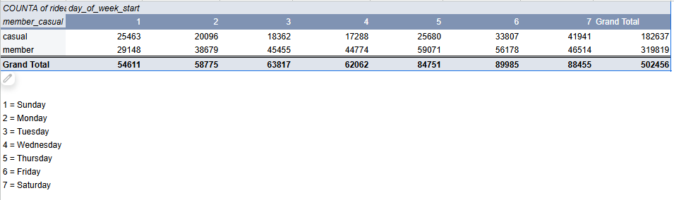

**Pivot Table of Popular Starting Stations:**

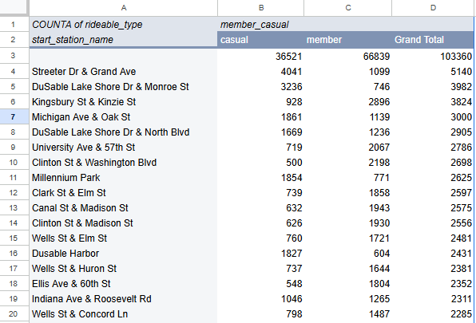

We then exported the cleaned data as a new `.csv` file for SQL and R analysis. Below is a preview of 100 observations from the cleaned dataset:

```r
DT::datatable(head(clean_data, 100),
              caption = "Clean CSV Data Preview")
```

|  | rideable_type | started_at | ended_at | start_station_name | end_station_name | member_casual | day_of_week_start |
| --- | --- | --- | --- | --- | --- | --- | --- |
| 1 | classic_bike | 2025-04-30 2:18:22 | 2025-05-01 3:18:16 | Desplaines St &amp; Kinzie St |  | casual | 4 |
| 2 | classic_bike | 2025-04-30 2:48:51 | 2025-05-01 3:48:47 | Parkside Ave &amp; Armitage Ave |  | casual | 4 |
| 3 | classic_bike | 2025-04-30 6:08:19 | 2025-05-01 7:07:57 | Morgan St &amp; 31st St |  | casual | 4 |
| 4 | classic_bike | 2025-04-30 6:49:21 | 2025-05-01 7:49:00 | Racine Ave &amp; Congress Pkwy |  | casual | 4 |
| 5 | classic_bike | 2025-04-30 7:33:03 | 2025-05-01 8:32:58 | Lake Park Ave &amp; 53rd St |  | member | 4 |
| 6 | classic_bike | 2025-04-30 10:35:37 | 2025-05-01 11:35:16 | Wabash Ave &amp; 16th St |  | casual | 4 |
| 7 | classic_bike | 2025-04-30 11:02:43 | 2025-05-01 12:02:36 | Michigan Ave &amp; 8th St |  | casual | 4 |
| 8 | classic_bike | 2025-04-30 11:12:07 | 2025-05-01 0:34:11 | Wilton Ave &amp; Diversey Pkwy | Sheffield Ave &amp; Fullerton Ave | casual | 4 |
| 9 | classic_bike | 2025-04-30 11:56:30 | 2025-05-01 12:56:10 | Aberdeen St &amp; Randolph St |  | casual | 4 |
| 10 | classic_bike | 2025-04-30 14:28:05 | 2025-05-01 9:06:43 | Daley Center Plaza | Streeter Dr &amp; Grand Ave | casual | 4 |

[output cut: 90 more lines]

## Data Aggregation with SQL (BigQuery)

We imported the dataset into **Google BigQuery** to perform efficient queries for aggregating and analyzing the data.

Examples of queries used:

- **Average ride length (minutes) by user type:**

```sql
SELECT
  member_casual,
  ROUND(AVG(TIMESTAMP_DIFF(ended_at, started_at, MINUTE)),1) AS avg_ride_length_minutes,
  count(ride_id) AS number_of_trips
FROM
  `premium-arc-461219-a7.Cyclistic_Data.trips_info`
GROUP BY member_casual
```

```r
knitr::kable(avg_rides, caption = "SQL Query Result: Avg Ride   Length by User Type")
```

SQL Query Result: Avg Ride Length by User Type

| member_casual | avg_ride_length_minutes | number_of_trips |
| --- | --- | --- |
| casual | 23.3 | 182637 |
| member | 11.6 | 319819 |

This query revealed an important distinction. Members take nearly twice as many rides as casual riders, but casual riders have ride durations that are almost double those of members.

- **Ride counts by day of week:**

```sql
SELECT
  member_casual,
  CASE day_of_week_start
    WHEN 1 THEN 'Sunday'
    WHEN 2 THEN 'Monday'
    WHEN 3 THEN 'Tuesday'
    WHEN 4 THEN 'Wednesday'
    WHEN 5 THEN 'Thursday'
    WHEN 6 THEN 'Friday'
    WHEN 7 THEN 'Saturday'
  END AS day_of_week,
  COUNT(*) AS ride_count
FROM
`premium-arc-461219-a7.Cyclistic_Data.trips_info`
GROUP BY
  member_casual,
  day_of_week_start
ORDER BY
  day_of_week_start
```

```r
knitr::kable(day_of_week_rides, caption = "SQL Query Result:Ride Counts by Day of Week")
```

SQL Query Result:Ride Counts by Day of Week

| member_casual | day_of_week | ride_count |
| --- | --- | --- |
| member | Sunday | 29148 |
| casual | Sunday | 25463 |
| casual | Monday | 20096 |
| member | Monday | 38679 |
| member | Tuesday | 45455 |
| casual | Tuesday | 18362 |
| member | Wednesday | 44774 |
| casual | Wednesday | 17288 |
| member | Thursday | 59071 |
| casual | Thursday | 25680 |
| member | Friday | 56178 |
| casual | Friday | 33807 |
| casual | Saturday | 41941 |
| member | Saturday | 46514 |

This query shows that while members and casual riders take a similar number of rides on weekends, members significantly outpace casuals during weekdays. This leads us to hypothesize: Could members be using Cyclistic both as a commuting solution during the week and for recreation on weekends, while casual riders use it mainly for leisure on weekends? Further analysis is needed.

- **Top 10 starting stations:**

```sql
SELECT
  member_casual,
  start_station_name,
  COUNT(*) AS number_of_rides
FROM
  `premium-arc-461219-a7.Cyclistic_Data.trips_info`
GROUP BY
  member_casual,
  start_station_name
ORDER BY
  number_of_rides DESC
LIMIT
  10
```

```r
knitr::kable(popular_stations, caption = "SQL Query Result:Top 10 Starting Stations")
```

SQL Query Result:Top 10 Starting Stations

| member_casual | start_station_name | number_of_rides |
| --- | --- | --- |
| member | NA | 66839 |
| casual | NA | 36521 |
| casual | Streeter Dr & Grand Ave | 4041 |
| casual | DuSable Lake Shore Dr & Monroe St | 3236 |
| member | Kingsbury St & Kinzie St | 2896 |
| member | Clinton St & Washington Blvd | 2198 |
| member | University Ave & 57th St | 2067 |
| member | Canal St & Madison St | 1943 |
| member | Clinton St & Madison St | 1930 |
| casual | Michigan Ave & Oak St | 1861 |

This query revealed two insights. First, casual and member riders have distinct favorite start stations. Second, we are missing a substantial amount of information: over 103,000 records have NULL values for the `start_station_name` field.

- **Top 10 routes:**

```sql
SELECT
  member_casual,
  CONCAT(start_station_name, ' to ', end_station_name) as route,
  count(*) as route_count
FROM
  `premium-arc-461219-a7.Cyclistic_Data.trips_info`
GROUP BY
  member_casual,
  route
ORDER BY
  route_count DESC
LIMIT
  10
```

```r
knitr::kable(popular_route, caption = "SQL Query Result:Top 10 Routes")
```

SQL Query Result:Top 10 Routes

| member_casual | route | route_count |
| --- | --- | --- |
| member | NA | 104820 |
| casual | NA | 57002 |
| casual | DuSable Lake Shore Dr & Monroe St to DuSable Lake Shore Dr & Monroe St | 670 |
| casual | Streeter Dr & Grand Ave to Streeter Dr & Grand Ave | 651 |
| casual | DuSable Lake Shore Dr & Monroe St to Streeter Dr & Grand Ave | 518 |
| member | University Ave & 57th St to Ellis Ave & 60th St | 514 |
| member | Ellis Ave & 60th St to University Ave & 57th St | 501 |
| casual | Michigan Ave & Oak St to Michigan Ave & Oak St | 328 |
| member | Ellis Ave & 55th St to Ellis Ave & 60th St | 309 |
| casual | Dusable Harbor to Dusable Harbor | 308 |

This query gave us the most common routes for each user type. However, due to the high number of NULL values in both `start_station_name` and `end_station_name`, the insights are limited.

After conducting SQL analysis, we turned to R for further exploration and visualization.

## Visualizations and Analysis in R

We visualized and manipulated the data in **R** using the **tidyverse**, **lubridate**, and **ggplot2** packages to confirm or reject our earlier hypothesis and gain deeper insights into how casual and member riders use Cyclistic differently.

- **Top 10 starting stations by user type:**

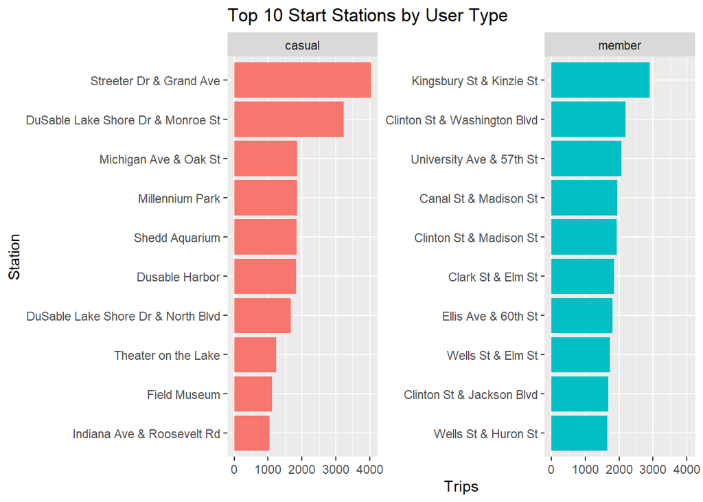

```r
df_trips %>%
  filter(!is.na(start_station_name)) %>%
  group_by(member_casual, start_station_name) %>%
  summarise(trips = n()) %>%
  slice_max(trips, n = 10, with_ties = FALSE) %>%
  ggplot(aes(x = reorder(start_station_name, trips), y = trips, fill = member_casual)) +
  geom_col(show.legend = FALSE) +
  coord_flip() +
  facet_wrap(~member_casual, scales = "free_y") +
  labs(title = "Top 10 Start Stations by User Type", x = "Station", y = "Trips")
```

This visualization supports our earlier observation: the top start stations differ between casual and member users. Casuals tend to start rides at recreational areas (e.g., museums, parks, theaters), whereas members start rides more often from streets and commercial zones.

- **Ride start time by hour of day:**

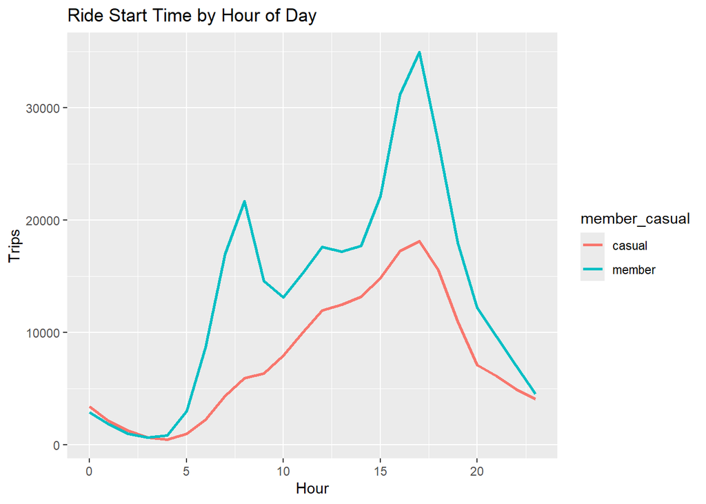

```r
df_trips %>%
  mutate(hour = hour(started_at)) %>%
  group_by(member_casual, hour) %>%
  summarise(trip_count = n()) %>%
  ggplot(aes(x = hour, y = trip_count, color = member_casual)) +
  geom_line(size = 1) +
  labs(title = "Ride Start Time by Hour of Day", x = "Hour", y = "Trips")
```

This chart reveals an interesting pattern. Members exhibit two prominent peaks: one around 8 AM and another around 5 PM—likely reflecting commute hours. In contrast, casual usage steadily increases throughout the day and peaks around 5 PM. This supports our commuting hypothesis. We explored further by splitting the data by weekday.

- **Ride start time by hour of day, separated by week day:**

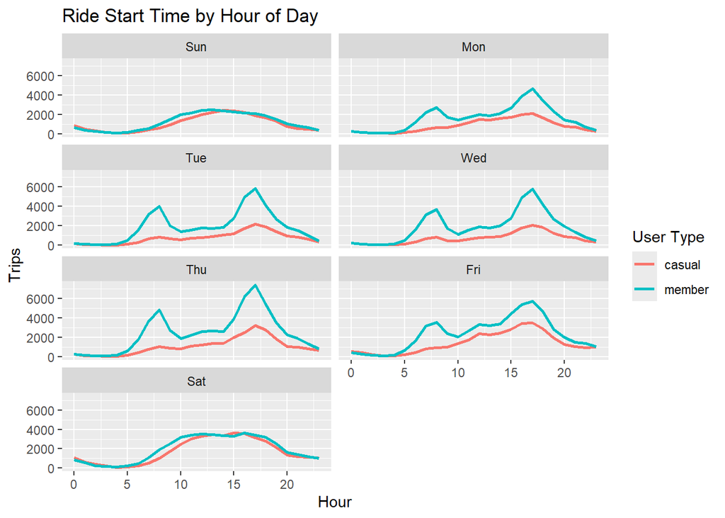

```r
df_trips %>%
  mutate(hour = hour(started_at),
         day_of_week = wday(started_at, label = TRUE)) %>%
  group_by(member_casual, hour, day_of_week) %>%
  summarise(trip_count = n(), .groups = "drop") %>%
  ggplot(aes(x = hour, y = trip_count, color = member_casual)) +
  geom_line(size = 1) +
  facet_wrap(~ day_of_week, ncol = 2) +
  labs(title = "Ride Start Time by Hour of Day",
       x = "Hour",
       y = "Trips",
       color = "User Type")
```

This breakdown adds further evidence: the dual commuting peaks for members disappear on Saturdays and Sundays, and both groups follow similar usage patterns on weekends—likely tied to leisure activities.

## Key Findings and Recommendations

### Facts:

- Casual riders prefer weekends and longer rides
- Members ride more frequently, have shorter rides, and peak during weekday commute hours
- Both groups ride similarly on weekends
- Casual riders favor recreational area stations
- Members start rides from streets and transport-oriented locations

### Hypothesis:

Members likely use Cyclistic both for commuting during the week and for recreation on weekends. Casual riders primarily use it for leisure, especially on weekends. However, more data is needed to validate this.

### Recommendations for Further Research:

1. Conduct post-ride surveys asking users their purpose for using Cyclistic
2. Address the NULL values in start and end station fields
3. Collect demographic data for richer segmentation

### Recommendations to Convert Casual Riders:

1. Promote membership benefits via email campaigns
2. Offer a free one-week trial to casual users
3. Highlight time and cost savings of membership (e.g., avoiding traffic, saving on gas)
4. Place promotional signage at popular casual riders stations with clear calls to action like “Switch Now!”

## Conclusion

The insights gathered throughout this analysis suggest that the two groups use the bike-share system for fundamentally different purposes—members primarily for daily transportation, and casuals for recreation.

Although the data supports this hypothesis, there are limitations—particularly the large number of missing values in station data and the absence of contextual user information like trip purpose or demographics.

Ultimately, this analysis provides a strong foundation for designing targeted marketing strategies. By addressing data limitations and acting on these behavioral insights, Cyclistic has the opportunity to convert more casual riders into committed annual members.